# Assignment: Prediction Assignment Writeup

Najiha

March 29, 2016

# Introduction

## Background

Using devices such as Jawbone Up, Nike FuelBand, and Fitbit it is now possible to collect a large amount of data about personal activity relatively inexpensively. These type of devices are part of the quantified self movement - a group of enthusiasts who take measurements about themselves regularly to improve their health, to find patterns in their behavior, or because they are tech geeks. One thing that people regularly do is quantify how much of a particular activity they do, but they rarely quantify how well they do it. In this project, your goal will be to use data from accelerometers on the belt, forearm, arm, and dumbell of 6 participants. They were asked to perform barbell lifts correctly and incorrectly in 5 different ways. More information is available from the website here: http://groupware.les.inf.puc-rio.br/har (see the section on the Weight Lifting Exercise Dataset).

## Data

The training data for this project are available here:

https://d396qusza40orc.cloudfront.net/predmachlearn/pml-training.csv

The test data are available here:

https://d396qusza40orc.cloudfront.net/predmachlearn/pml-testing.csv

The data for this project come from this source: http://groupware.les.inf.puc-rio.br/har. If you use the document you create for this class for any purpose please cite them as they have been very generous in allowing their data to be used for this kind of assignment.

## Load Data

```r
library(caret)
library(randomForest)
```

```r
library(rpart) # Regressive Partitioning and Regression trees
library(rpart.plot) # Decision Tree plot
library(RColorBrewer)

set.seed(1234)

training = data.frame(read.csv("/Users/najiha/Desktop/mypersonal/cousera/quiz4-module8/pml-training.csv"))
testing = data.frame(read.csv("/Users/najiha/Desktop/mypersonal/cousera/quiz4-module8/pml-testing.csv"))
```

Partioning the training set into two (split data)

```r
inTrain <- createDataPartition(y=training$classe, p=0.6, list=FALSE)
myTraining <- training[inTrain, ];
myTesting <- training[-inTrain, ]

dim(myTraining); dim(myTesting)
```

```
## [1] 11776   160
```

```
## [1] 7846  160
```

## Cleaning the data

```r
# Remove value using nearZeroVar().
nzv <- nearZeroVar(myTraining, saveMetrics=TRUE)
myTraining <- myTraining[,nzv$nzv==FALSE]

nzv<- nearZeroVar(myTesting,saveMetrics=TRUE)
myTesting <- myTesting[,nzv$nzv==FALSE]

# Remove NA value
myTraining <- myTraining[ , colSums(is.na(myTraining)) == 0]
myTesting <- myTesting[ , colSums(is.na(myTesting)) == 0]

# Remove first ID of variable
myTraining <- myTraining[c(-1)]
myTesting <- myTesting[c(-1)]
```

## Random Forest

```r
RFmodel  <- randomForest(classe ~. , data=myTraining, method="class")

# Predicting:
prediction1 <- predict(RFmodel, myTesting, type = "class")

# Test results on subTesting data set:
confusionMatrix(prediction1, myTesting$classe)
```

```
## Confusion Matrix and Statistics
##
##           Reference
## Prediction    A    B    C    D    E
##          A 2232    2    0    0    0
##          B    0 1516    5    0    0
##          C    0    0 1362    5    0
##          D    0    0    1 1280    1
##          E    0    0    0    1 1441
##
## Overall Statistics
##
##                Accuracy : 0.9981
##                  95% CI : (0.9968, 0.9989)
##     No Information Rate : 0.2845
##     P-Value [Acc > NIR] : < 2.2e-16
##
##                   Kappa : 0.9976
##  Mcnemar's Test P-Value : NA
##
## Statistics by Class:
##
##                      Class: A Class: B Class: C Class: D Class: E
## Sensitivity            1.0000   0.9987   0.9956   0.9953   0.9993
## Specificity            0.9996   0.9992   0.9992   0.9997   0.9998
## Pos Pred Value         0.9991   0.9967   0.9963   0.9984   0.9993
## Neg Pred Value         1.0000   0.9997   0.9991   0.9991   0.9998
## Prevalence             0.2845   0.1935   0.1744   0.1639   0.1838
## Detection Rate         0.2845   0.1932   0.1736   0.1631   0.1837
## Detection Prevalence   0.2847   0.1939   0.1742   0.1634   0.1838
## Balanced Accuracy      0.9998   0.9989   0.9974   0.9975   0.9996
```

## Decision Tree

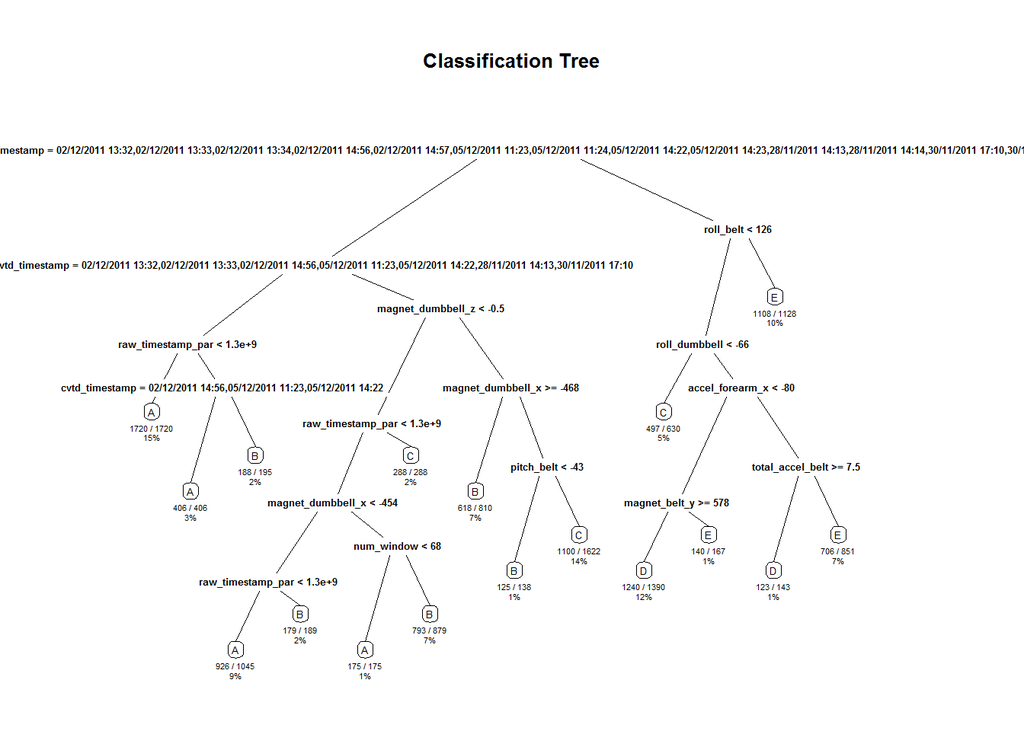

```r
# Fit model
DTmodel <- rpart(classe ~ ., data=myTraining, method="class")

# Perform prediction
prediction2 <- predict(DTmodel, myTesting, type = "class")

# Plot result
rpart.plot(DTmodel, main="Classification Tree", extra=102, under=TRUE, faclen=0)
```

```r
confusionMatrix(prediction2, myTesting$classe)
```

```
## Confusion Matrix and Statistics
##
##           Reference
## Prediction    A    B    C    D    E
##          A 2161   61    5    3    0
##          B   50 1271   95   64    0
##          C   21  177 1242  203   65
##          D    0    9   19  899   92
##          E    0    0    7  117 1285
##
## Overall Statistics
##
##                Accuracy : 0.8741
##                  95% CI : (0.8665, 0.8813)
##     No Information Rate : 0.2845
##     P-Value [Acc > NIR] : < 2.2e-16
##
##                   Kappa : 0.8407
##  Mcnemar's Test P-Value : NA
##
## Statistics by Class:
##
##                      Class: A Class: B Class: C Class: D Class: E
## Sensitivity            0.9682   0.8373   0.9079   0.6991   0.8911
## Specificity            0.9877   0.9670   0.9281   0.9817   0.9806
## Pos Pred Value         0.9691   0.8588   0.7272   0.8822   0.9120
## Neg Pred Value         0.9874   0.9612   0.9795   0.9433   0.9756
## Prevalence             0.2845   0.1935   0.1744   0.1639   0.1838
## Detection Rate         0.2754   0.1620   0.1583   0.1146   0.1638
## Detection Prevalence   0.2842   0.1886   0.2177   0.1299   0.1796
## Balanced Accuracy      0.9779   0.9021   0.9180   0.8404   0.9359
```